# R Code I Have Found Useful

Allo Thali

April 13, 2015

This an utterly haphazard collection of code examples I have found (still find) useful.

It is not organized in any sensible fashion and readers other than myself may not even bother.

This first thing that occurs to me: the Hadley collection of libraries.

Next, there are a number of simple functions that seem to have recurring use in my code.

```r
##  the simplest, saves miniscule amount of typing
rnd4 <- function(x){round(x, 4)}
```

A lot of stuff in my experience tend to be logathmic, and occassionally negative.

```r
##  "log modulus"
##  http://www.statsblogs.com/2014/07/14/a-log-transformation-of-positive-and-negative-values/
log_mod <- function(x){sign(x) * log10(abs(x + 1))}
```

Compare…

```r
log10(-1000)
```

```
## [1] NaN
```

```r
rnd4(log_mod(-1000))
```

```
## [1] -2.9996
```

Often need to put timing of events into a fiscal year context, so…

```r
##  converting to a company specific fiscal quarter and year
##  requires lubridate, x is not a date, add as.Date(x)
my_fyq <- function(x){quarter(floor_date(x, "month") + months(11), with_year = TRUE)}
```

Compare…

```r
quarter(Sys.Date(), with_year = TRUE)
```

```
## [1] 2016.1
```

```r
my_fyq(Sys.Date())
```

```
## [1] 2016.4
```

This is function calculates 95% confidence intervals using the t-distribution.

```r
my_summary <- function(df, y_val, ...){
      ##  my_summary(df = iris, y_val = "Sepal.Length")
      ##  compare to t.test(iris$Sepal.Length)
      y_val <- as.name(y_val)

      df %>%
            group_by_(...) %>%
            summarize(samp_size = n(),
                      y_mean = rnd4(mean(y_val)),
                      y_sd = rnd4(sd(y_val)),
                      ll = rnd4(y_mean - qt(0.975, df = samp_size - 1) * y_sd / sqrt(samp_size)),
                      ul = rnd4(y_mean + qt(0.975, df = samp_size - 1) * y_sd / sqrt(samp_size))
                      ) %>%
            data.frame()
}
```

Compare…

```r
my_summary(df = iris, y_val = "Sepal.Length")
```

```
##   samp_size y_mean   y_sd     ll     ul
## 1       150 5.8433 0.8281 5.7097 5.9769
```

```r
t.test(iris$Sepal.Length)
```

```
##
##  One Sample t-test
##
## data:  iris$Sepal.Length
## t = 86.425, df = 149, p-value < 2.2e-16
## alternative hypothesis: true mean is not equal to 0
## 95 percent confidence interval:
##  5.709732 5.976934
## sample estimates:
## mean of x
##  5.843333
```

With my version, can do this by Species.

```r
my_summary(df = iris, y_val = "Petal.Length", "Species")
```

```
##      Species samp_size y_mean   y_sd     ll     ul
## 1     setosa        50  1.462 0.1737 1.4126 1.5114
## 2 versicolor        50  4.260 0.4699 4.1265 4.3935
## 3  virginica        50  5.552 0.5519 5.3952 5.7088
```

This uses the same idea for a binomial variable using a normal distribution

```r
##  slighly more involved, get confidence intervals from binomial data. e.g. satisfaction
summarize_sat <- function(df, th, ...){
      ##  df is the dataframe with a column called score
      ##  th is the threshold, e.g. satisfaction is >=7 on 11 point scale
      ##  ... allows lazy group bys
      df %>%
            group_by_(...) %>%
            summarize(perc = 100 * rnd4(mean(score >= th, na.rm = TRUE)),
                      numer = sum(score >= th, na.rm = TRUE),
                      # n_distinct() also works
                      denom = length(unique(survey_id)),
                      # binomial ci
                      se = sqrt(perc * (100 - perc) / denom),
                      ll = perc - rnd4(abs(qnorm(.05/2)) * se),
                      ul = perc + rnd4(abs(qnorm(.05/2)) * se))
}
```

Occassionally, hit upon a chart style that I want re-use.

```r
##  an example of a charting function if end up doing the same thing over and over
my_plot <- function(df, x_val, y_val, z_val){
      ##  note as.name and aes_string
      ##  my_plot(df = iris, x_val = "Sepal.Length", y_val = "Sepal.Width", z_val = "Species")
      x_val <- as.name(x_val)
      y_val <- as.name(y_val)
      my_clrs <- c("black", "steelblue", "orangered")

      ggplot(df,
             aes_string(x = x_val,
                        y = y_val,
                        colour = z_val,
                        shape = z_val,
                        linetype = z_val,
                        group = z_val)) +
            geom_point(size = 4,
                       position = position_jitter(w = .05, h = .05),
                       alpha = I(3/4)) +
            scale_colour_manual(values = my_clrs) +
            theme_light(base_size = 12)
}
```

Compare…

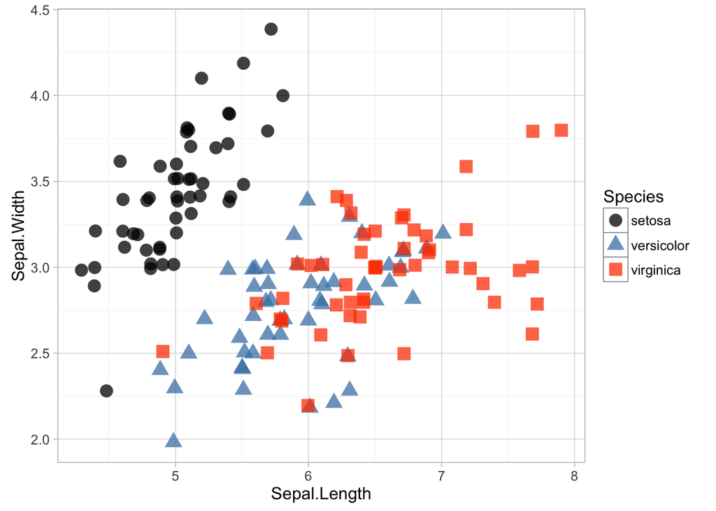

```r
my_plot(df = iris, x_val = "Sepal.Length", y_val = "Sepal.Width", z_val = "Species")
```

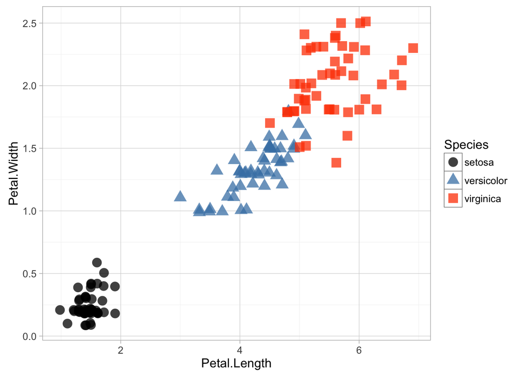

```r
my_plot(df = iris, x_val = "Petal.Length", y_val = "Petal.Width", z_val = "Species")
```

Another trick is to use a plotting function to loop through data and applying a filter.

Loop through iris data (which in the case of iris is kinda dumb, see above)

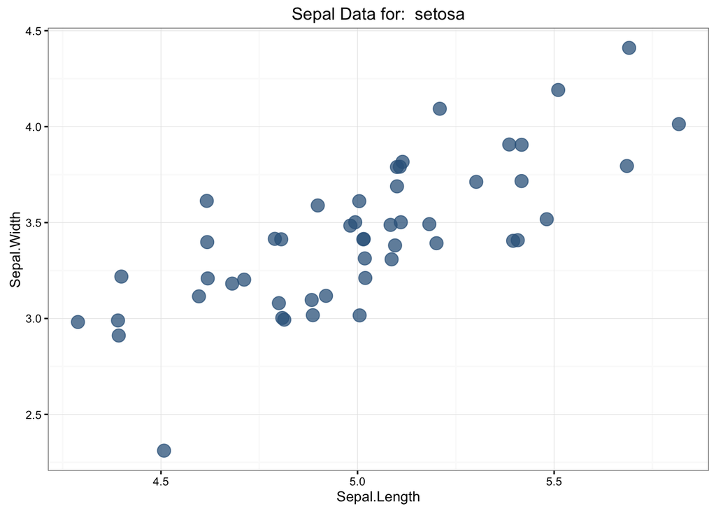

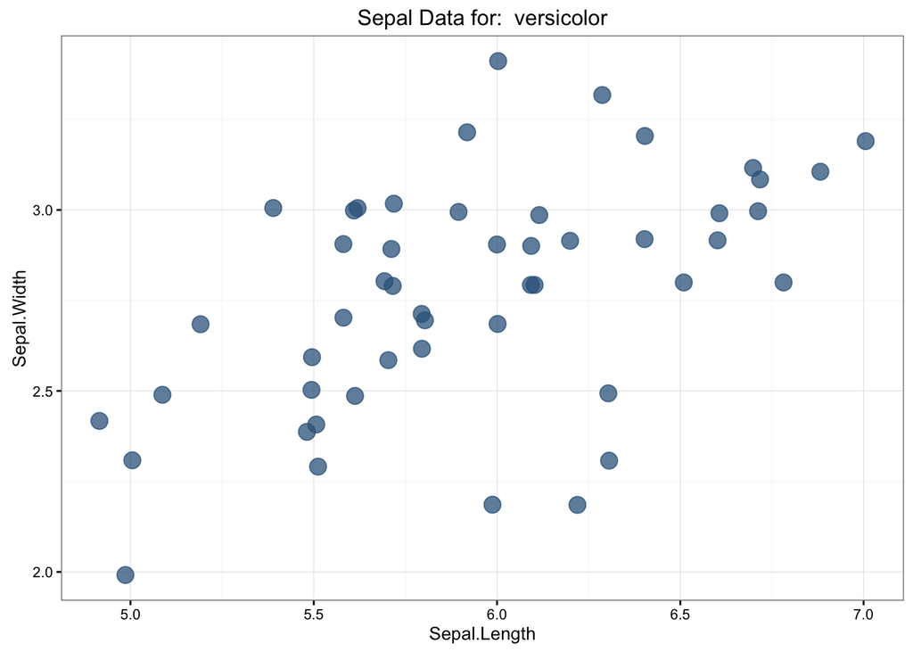

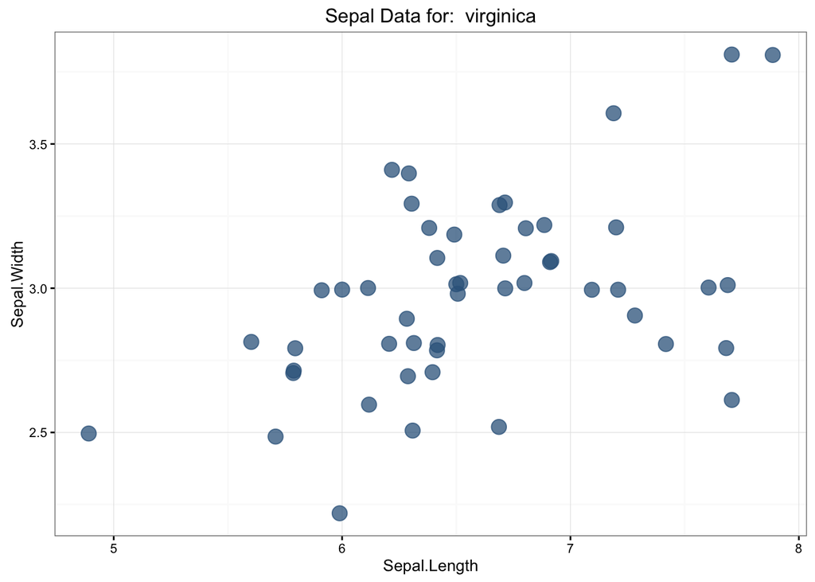

```r
for (i in unique(iris$Species)) {
      for_plots <- ggplot(filter(iris, as.character(Species) == i),
             aes(x = Sepal.Length, y = Sepal.Width)) +
            geom_point(size = 4,
                       position = position_jitter(w = .05, h = .05),
                       alpha = I(3/4),
                       colour = "steelblue4") +
            labs(title = paste0("Sepal Data for:  ", i)) +
            theme_bw(base_size = 10)
      print(for_plots)
      }
```

One of my favorite sorts of charts: boxplot with jittered data points

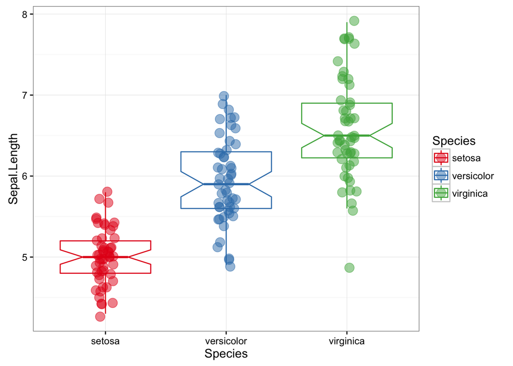

```r
ggplot(iris, aes(x = Species, y = Sepal.Length, colour = Species)) +
      geom_boxplot(outlier.shape = NA, notch = TRUE) +
      geom_jitter(position = position_jitter(w = 0.2), size = 4, alpha = I(1/2)) +
      scale_colour_brewer(palette = "Set1") +
      theme_bw(base_size = 12)
```

Latex example using Customer Lifetime Value: A simplified model ([Gupta et al. 2006](http://www.anderson.ucla.edu/faculty/dominique.hanssens/content/JSR2006.pdf)):

`$$CLV = \displaystyle\sum_{i=0}^{\infty}\frac{(p - c)r^t}{(1 + i)^t} = m\frac{r}{(1 + i - r)}$$`
$$CLV = \displaystyle\sum_{i=0}^{\infty}\frac{(p - c)r^t}{(1 + i)^t} = m\frac{r}{(1 + i - r)}$$

This simplification assumes stable margins and retention rates over an infinite period.

If we assume constants:

- discount rate = $i$ = 15%
- margin = $m$ = $255/seat

```r
i <- .15
m <- 255
d <- data.frame(r = round(seq(from = .8, to = 1, by = .01), 2))
fx_ltv <- function(x){round(m * x / (1 + i - x), 0)}
d <- mutate(d, slv = fx_ltv(r))
```

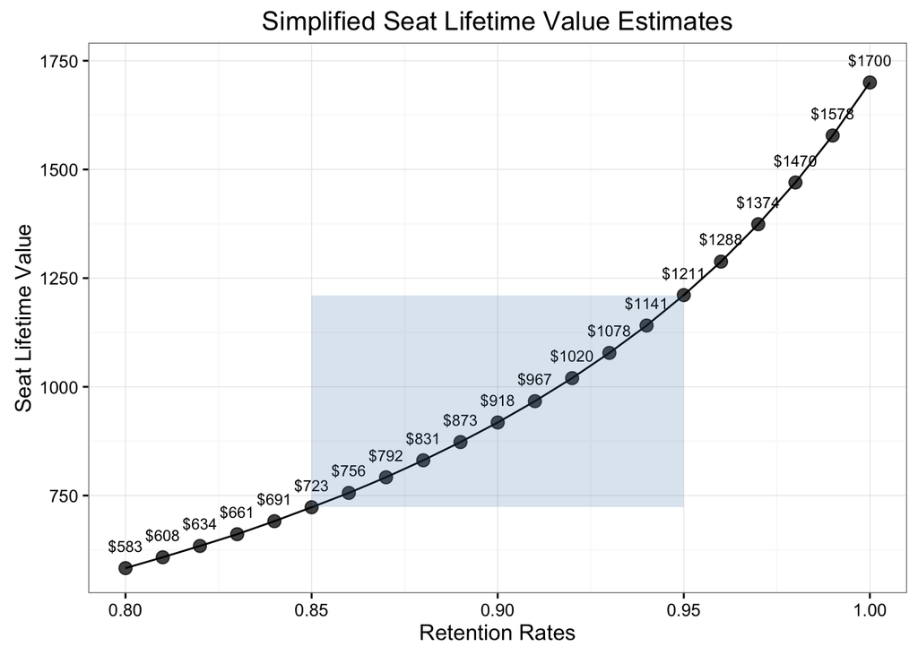

Depending on churn rate, the liftime value for every 1000 seats could realistically be anywhere from:

- `$723000`
- `$1211000`

Very often, export at the end.

```r
write.table(df_of_interest,
            "~/Downloads/data_of_interest.csv",
            col.names = TRUE,
            row.names = FALSE,
            sep = ",")

## or
library(readr)

write_csv(df_of_interest, "~/Downloads/data_of_interest.csv")
```